# Final Project

Elizabeth Hora

3/19/2021

## Loading Packages

```r
library(tidyverse)
library(gganimate)
library(broom)
library(readxl)
library(lubridate)
library(lvplot)
library(janitor)
library(parsnip)
library(tidymodels)
library(corrplot)
```

## Data Source

The information that I will use for my final project is provided by the Massachusetts Department of Transportation, or [MassDOT](https://mhd.ms2soft.com/tcds/tsearch.asp?loc=Mhd&mod=) for short. MassDOT provides public access to a Transportation Data Management System, which has multiple types of data: counts of vehicles per hour at a given location per day per month (`volume`), which way cars drive through a particular intersection (`location`: `AET09` for Framingham-`fr`, `AET10` for Cochituate-`co`, `AET11` for Newton-`ne`, `AET12` for pre Alston Interchange-`pre`, and `AET13` for post Alston Interchange-`po`; `direction`: `EB` for East Bound or `WB` for West Bound), a range how fast cars traveled on average at given times (`speed`), and the type of vehicle traveling past the sensor (`class`). The data that I will focus on are located on different locations along the Massachusetts Turnpike (Mass Pike). In the previous quarter, I manually downloaded all the Excel files. In this quarter, using Jupyter Notebook to run a python script my Dad helped me write, I could download all the files automatically (As shown in the *Downloading Data* section). Using the `readxl` package, I was able to load the *Excel* files into tibbles, which I worked with using techniques learned in class so far. I downloaded several years’ worth of data for particular intersections by downloading the monthly reports available for a given year. Each monthly report has a similar name format from a python `wget` script that my Dad helped me engineer, which was a major improvement this time around. Instead of spending hours manually downloading everything, this python script goes through a list of locations, months, years, `class`, `speed`, and `volume` and stores the *Excel* files on my computer, where I can move them into the folder for my final project. I unfortunately do not have the time to investigate the `elm_street`, or *Concord Rotary*, location as I did last quarter.

## Geography

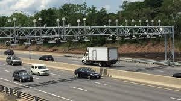

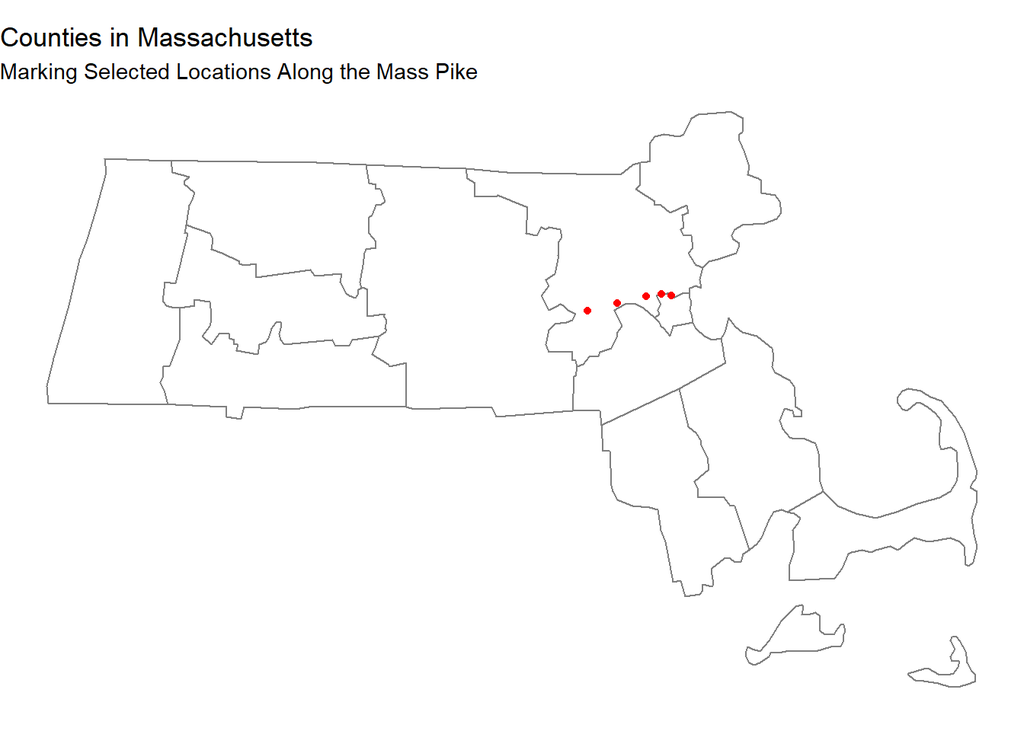

```r
# Part 1
ma_counties <- ggplot2::map_data("county", "massachusetts") %>%
  dplyr::select(lon = long, lat = lat, group, id = subregion)


# Part 2
ma_important_places <- tribble(
  ~city, ~latitude, ~longitude,
  "Framingham", 42.309515, -71.436233,
  "Cochituate", 42.331647, -71.322605,
  "Newton", 42.350590, -71.211140,
  "Pre Alston Interchange", 42.357814, -71.153235,
  "Post Alston Interchange", 42.352682, -71.115337

)

# Part 3
ggplot(ma_counties, aes(lon, lat)) +
  geom_polygon(aes(group = group), fill = "white", colour = "grey50") +
  geom_point(data = ma_important_places, mapping = aes(x = longitude, y = latitude), color = "RED") +
  coord_quickmap() +
  theme_void() +
  labs(
    title = "Counties in Massachusetts",
    subtitle = "Marking Selected Locations Along the Mass Pike"
  )
```

## Why These Data

Choosing to look at traffic data for my final project in *STAT 301-1* has really influenced me. I think it is because the data have a connection to my family and other families across the state with family members that commute to Boston (at least before the pandemic). I’m interested to see if traffic has changed over time with the increasing registration of vehicles each year, and even more interested in seeing if I can quantify this change. I would also like to see if traffic has significantly improved with less cars on the road from more people working from home because of COVID. The common prescribed remedy for the ailment of rush hour traffic is congestion pricing. I want to see if in fact less cars on the road in 2020 has dramatically improved conditions. The main challenges for me have been processing the data based on `volume`, `class`, and `speed` from MassDOT and to make the right comparisons to properly analyze the data.

## Downloading the Data

```r
# Python Code:
import wget

years = list(range(2016,2021))
months = list(range(1,13))
location_list = ["AET09", "AET10", "AET11", "AET12", "AET13"]
direction_list = ["EB", "WB"]


for locationcode in location_list:
    for direction in direction_list:
        for year in years:
            for month in months:
                datecode = str(year)+"-"+str(month).zfill(2)+"-01"
                url_base = "https://mhd.ms2soft.com/tcds/file_download.aspx?agency_id=96&tcds_user_type="
                url_volume = url_base + "USER&format=excel&type=MonthlyVolume&abn=1&local_id=" + locationcode + "_" + direction + "&sdate=" + datecode
                url_speed = url_base + "USER&format=excel&type=MonthlyBin&i=8213126&abn=1&local_id=" + locationcode + "_" + direction + "&sdate=" + datecode +"&count_type=speed"
                url_class = url_base + "USER&format=excel&type=MonthlyBin&abn=1&local_id=" + locationcode + "_" + direction + "&sdate=" + datecode +"&count_type=class"
                wget.download(url_volume, 'c:/data/MonthlyVolumeReport_'+locationcode+"_"+direction+"_"+datecode+'.xlsx')
                wget.download(url_speed, 'c:/data/MonthlySpeedReport_'+locationcode+"_"+direction+"_"+datecode+'.xlsx')
                wget.download(url_class, 'c:/data/MonthlyClassReport_'+locationcode+"_"+direction+"_"+datecode+'.xlsx')
```

## Initial Data Issues

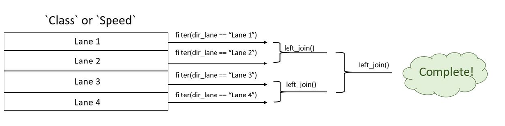

After downloading my data, I was faced with the challenge of processing each of the data sets for `class`, `speed`, and `volume.` I had already been able to read in my data from my code last quarter for volume. The tricky part was reading in class and speed with bins of values spread across multiple lanes. Although it would be an interesting question to see if there is a difference in flow between lanes, that is not one of my questions. All of my work was run in a separate R jobs (`Hora_Elizabeth_Final_Project_pike_job_class`, `Hora_Elizabeth_Final_Project_pike_job_speed`, `Hora_Elizabeth_Final_Project_pike_job_volume`) in the attached in this submission. A brief schematic of what I did to process the `speed` and `class` is the image below (the first and second left_join() each having their own function to rename columns):

## Solving the Data Issues

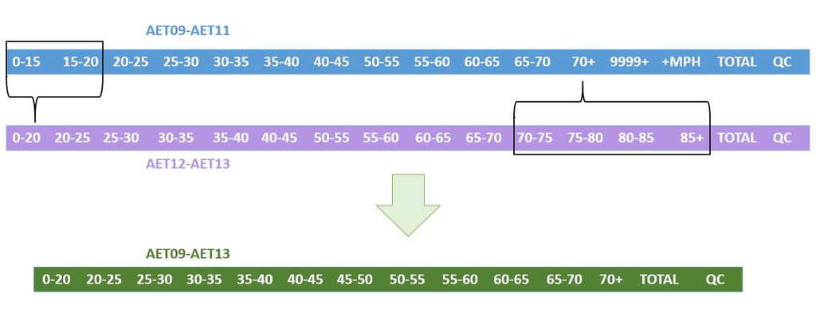

The processing for `class` went smoothly after defining my renaming functions and modified `left_join()` functions. However, the processing for `speed` was much more involved because locations `AET09`, `AET10`, and `AET11` had different columns than `AET12` and `AET13` (shown in the image above). After defining additional functions, I was able to combine all observations together.

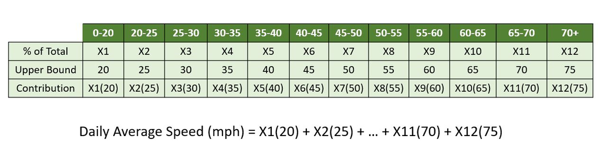

The first thing I notice is what I like to call the *NASA Category*, or the **9999+mph** speed range. Upon looking at the data, there were surprisingly instances of “people traveling at 13 times the speed of sound down the Mass Pike”, but those strange data points were excluded in the data processing steps, so I do not have to worry about NASA or SpaceX dragging up the average speeds for the day. To estimate the speed of cars traveling through different locations on the Mass Pike, I used a the sum of a calculated weighted average of each speed range to get a rough estimate of the daily average speed. This was limited to daily because both `class` and `speed` were collected on a per day basis. This calculation was inspired by the types of natural abundance of isotopes calculations that I learned in General Chemistry as a baby freshman.

## Reading in Data

```r
# Reading in saved rds files
pike_class_processed_data <- read_rds("pike_class_processed_data.rds")
pike_speed_processed_data <- read_rds("pike_speed_processed_data.rds")
pike_volume_processed_data <- read_rds("pike_volume_processed_data.rds")
```

The `pike_volume_processed_data` tibble appears to be much larger than the others, but since it is in tidy format, there are 24 rows per day. The `pike_class_processed_data` and `pike_speed_processed_data` are measured in days, so once the `pike_volume_processed_data` is divided by 24, there are the same number of observations as the others, which is good news.

## Complete Data

### Class

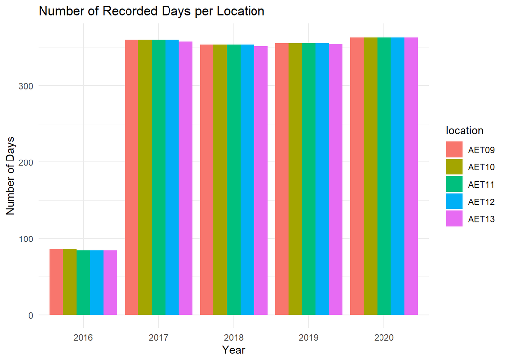

```r
# Collecting Information
pike_class_available <- pike_class_processed_data %>%
  mutate(year = as.factor(year(full_date))) %>%
  mutate(month = as.factor(month(full_date))) %>%
  filter(total != 0) %>%
  group_by(year, location, direction) %>%
  count()

# Plotting
ggplot(pike_class_available, aes(x = year, y = n, fill = location)) +
  geom_col(position = "dodge") +
  theme_minimal() +
  labs(
    title = "Number of Recorded Days per Location",
    y = "Number of Days",
    x = "Year"
  )
```

Nearly every year has observations every day. There is no concerning amount of missing data, so I can proceed without this being a concern.

### Speed

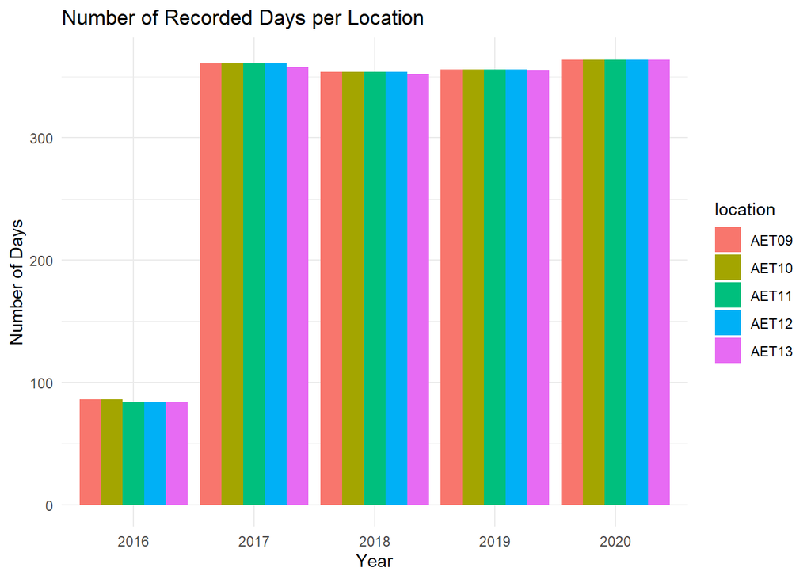

```r
# Collecting Information
pike_speed_available <- pike_speed_processed_data %>%
  mutate(year = as.factor(year(full_date))) %>%
  mutate(month = as.factor(month(full_date))) %>%
  filter(total != 0) %>%
  group_by(year, location, direction) %>%
  count()

# Plotting
ggplot(pike_speed_available, aes(x = year, y = n, fill = location)) +
  geom_col(position = "dodge") +
  theme_minimal() +
  labs(
    title = "Number of Recorded Days per Location",
    y = "Number of Days",
    x = "Year"
  )
```

Nearly every year has observations every day. There is no concerning amount of missing data, so I can proceed without this being a concern.

### Volume

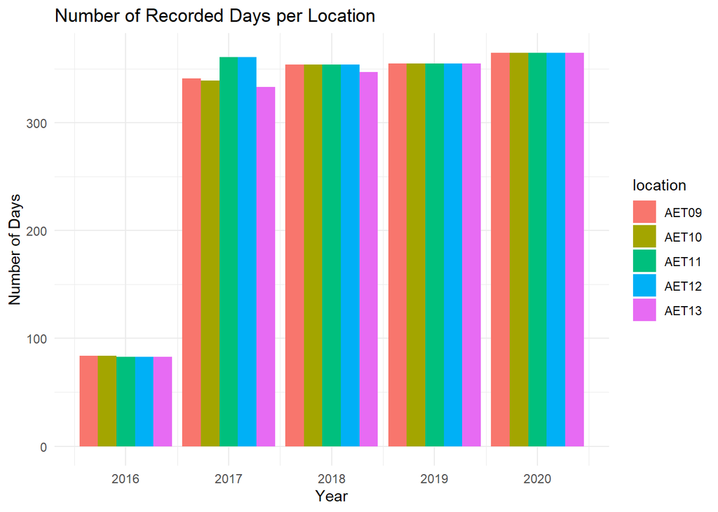

```r
# Collecting Information
pike_volume_available <- pike_volume_processed_data %>%
  group_by(year, location, direction) %>%
  filter(!is.na(cars_per_hour)) %>%
  count() %>%
  mutate(n = n / 24)

# Plotting
ggplot(pike_volume_available, aes(x = year, y = n, fill = location)) +
  geom_col(position = "dodge") +
  theme_minimal() +
  labs(
    title = "Number of Recorded Days per Location",
    y = "Number of Days",
    x = "Year"
  )
```

Nearly every year has observations every day, with just a bit less data than class or speed, but that is okay. There is no concerning amount of missing data, so I can proceed without this being a concern.

## Outlining the Model Process

The first sets of models I created predicted the `cars_per_hour` in 2020 based on data from 2016-2019. I ran a linear model, a random forest model, a boosted tree model, another boosted tree model with modified parameters, a nearest neighbor model, and a nearest neighbor model with adjusted parameters. Each of these models, except for the linear model, has a dedicated *RScript* to run separately as jobs. I initially ran some models on my computer, but my Dad offered me a different computer with better RAM and memory to be able to handle more extensive models. After receiving the results for these models, I decided to attempt to model the daily average speed of cars in 2020 based on available data from 2016-2019. Comparing how the number of cars passing through data collection points to how the average speed has changed would bring insight into traffic patterns and whether or not congestion pricing is a realistic solution to managing traffic.

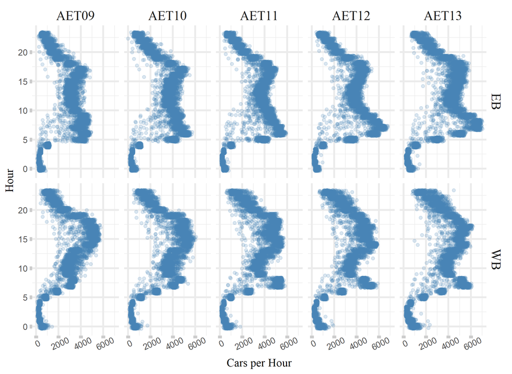

The distribution of points for cars_per_hour shows that data do not exhibit a linear relationship. Therefore, I would expect the linear model to perform poorly compared to the other modelling methods.

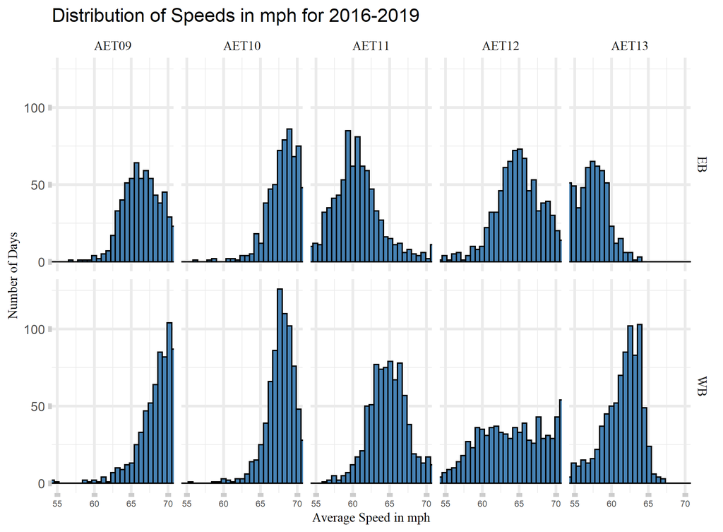

The distribution of points for vehicle class and speed shows that data do not exhibit a linear relationship. Therefore, I would expect the linear model to perform poorly compared to the other modelling methods.

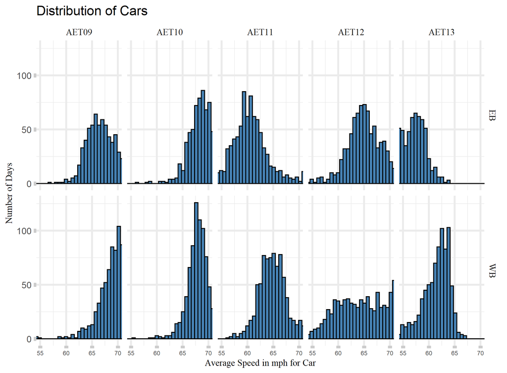

The distribution of cars looks a lot like the overall distribution, likely because cars make up a bulk of the data.

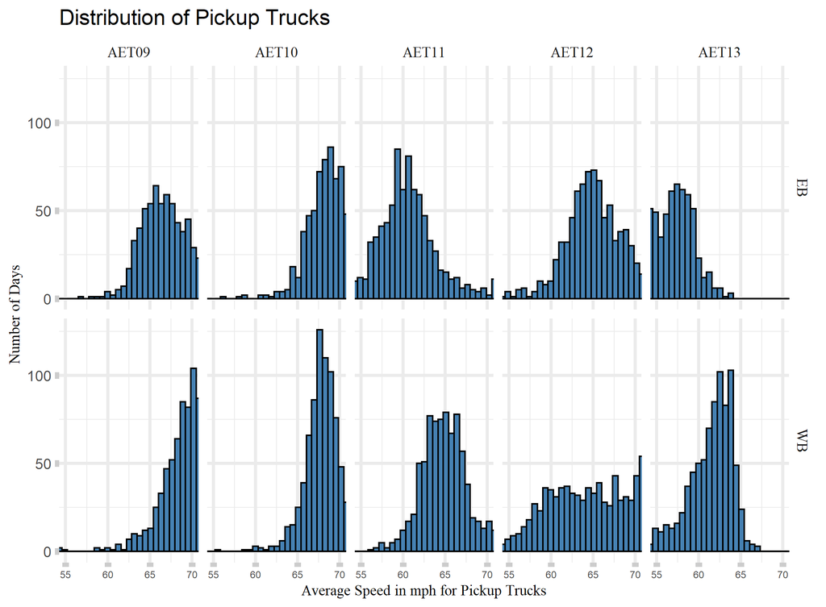

The distribution of pickup trucks looks a lot like the overall distribution, which also makes a fair amount of the distribution.

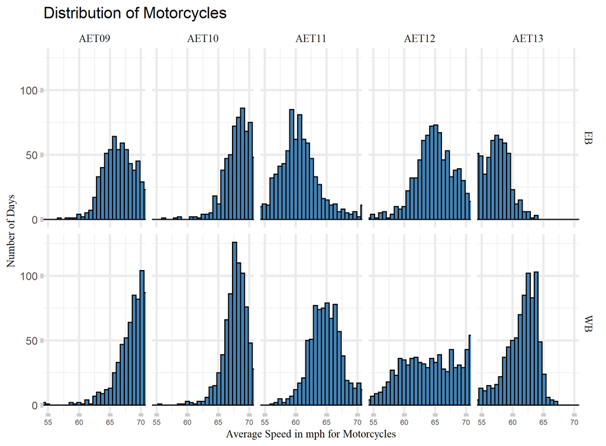

The distribution of motorcycles also looks fairly similar to the overall distribution, but there are not as many motorcycles on the roads.

## Splitting the Data

I had enough data (a whole year’s worth) to manually set as the test set and four year’s worth to set as the training set. In the different model types, I used `cars_per_hour` from 2016-2019 to predict `cars_per_hour` in 2020. I also did the same thing with `daily_sum` from 2016-2019 to predict the `daily_sum` in 2020.

```r
# Wrangling Volume Data
pike_volume_data <- pike_volume_processed_data %>%
  filter(day_of_week != "Sunday") %>%
  filter(day_of_week != "Saturday") %>%
  mutate(year = year(full_date)) %>%
  filter(!is.na(cars_per_hour)) %>%
  mutate(day_of_week = factor(day_of_week,
                              levels = c("Monday", "Tuesday", "Wednesday", "Thursday", "Friday")
                                ))

# Wrangling Class and Speed Data
pike_class_data <- read_rds("pike_class_processed_data.rds") %>%
  mutate(day_of_week = wday(full_date, label = TRUE, abbr = FALSE)) %>%
  filter(day_of_week != "Sunday") %>%
  filter(day_of_week != "Saturday") %>%
  mutate(year = year(full_date)) %>%
  mutate(day_of_week = factor(day_of_week,
                              levels = c("Monday", "Tuesday", "Wednesday", "Thursday", "Friday")
  )) %>%
  filter(total != 0)



pike_speed_data <- read_rds("pike_speed_processed_data.rds") %>%
  mutate(day_of_week = wday(full_date, label = TRUE, abbr = FALSE)) %>%
  filter(day_of_week != "Sunday") %>%
  filter(day_of_week != "Saturday") %>%
  mutate(year = year(full_date)) %>%
  mutate(month = month(full_date)) %>%
  mutate(day = day(full_date)) %>%
  mutate(day_of_week = factor(day_of_week,
                              levels = c("Monday", "Tuesday", "Wednesday", "Thursday", "Friday")
  )) %>%
  filter(total != 0)

pike_class_speed_data <- left_join(
  pike_class_data,
  pike_speed_data,
  by = c("direction", "location", "day_of_week", "year", "full_date", "total")
)


pike_class_speed_data_avg_speed <- pike_class_speed_data %>%
  group_by(total, direction, location, year, month, day) %>%
  mutate(x0_20_mph_wt = x0_20_mph/total,
         x20_25_mph_wt = x20_25_mph/total * 25,
         x25_30_mph_wt = x25_30_mph/total * 30,
         x30_35_mph_wt = x30_35_mph/total * 35,
         x35_40_mph_wt = x35_40_mph/total * 40,
         x40_45_mph_wt = x40_45_mph/total * 45,
         x45_50_mph_wt = x45_50_mph/total * 50,
         x50_55_mph_wt = x50_55_mph/total * 55,
         x55_60_mph_wt = x55_60_mph/total * 60,
         x60_65_mph_wt = x60_65_mph/total * 65,
         x65_70_mph_wt = x65_70_mph/total * 70,
         x70_mph_wt = x70_mph/total * 75
         ) %>%
  select(contains("wt")) %>%
  mutate(daily_sum = sum(c(x0_20_mph_wt, x20_25_mph_wt,
                         x25_30_mph_wt, x30_35_mph_wt,
                         x35_40_mph_wt, x40_45_mph_wt,
                         x45_50_mph_wt, x50_55_mph_wt,
                         x55_60_mph_wt, x60_65_mph_wt,
                         x65_70_mph_wt, x70_mph_wt))) %>%
  select(-contains("wt"))


pike_class_speed_joined <- left_join(
  pike_class_speed_data_avg_speed,
  pike_class_speed_data,
  by = c("direction", "location", "year", "total", "day" = "date", "month")
) %>%
  select(-day.y)



# Training Set for Volume
pike_volume_train <- pike_volume_data %>%
  filter(year != 2020) %>%
  select(-c(year))

# Testing Set for Volume
pike_volume_test <- pike_volume_data %>%
  filter(year == 2020) %>%
  select(-c(year))

# Training Set for Class and Speed
pike_class_speed_train <- pike_class_speed_joined %>%
  filter(year != 2020)

# Testing Set for Class and Speed
pike_class_speed_test <- pike_class_speed_joined %>%
  filter(year == 2020)
```

## Looking at Model Results for Volume

### Linear Model

```r
# Pike recipe
pike_recipe_linear <- recipe(cars_per_hour ~ ., data = pike_volume_train) %>%
  step_rm(full_date) %>%
  step_dummy(c(day_of_week, direction, location)) %>%
  step_ns(day, hour, month)


# Linear Model
linear_model <- linear_reg(penalty = tune(), mixture = tune()) %>%
  set_engine("lm")


# Test Workflow
pike_linear_workflow <- workflow() %>%
  add_model(linear_model) %>%
  add_recipe(pike_recipe_linear)

# Fitting the results
test_results <- fit(pike_linear_workflow, pike_volume_train)

# Setting my rmse metric
linear_metric_set <- metric_set(rmse)

# Creating a prediction
predict(test_results, new_data = pike_volume_test) %>%
  bind_cols(pike_volume_test %>% select(cars_per_hour)) %>%
  linear_metric_set(truth = cars_per_hour, estimate = .pred)
```

```
## # A tibble: 1 x 3
##   .metric .estimator .estimate
##   <chr>   <chr>          <dbl>
## 1 rmse    standard       1436.
```

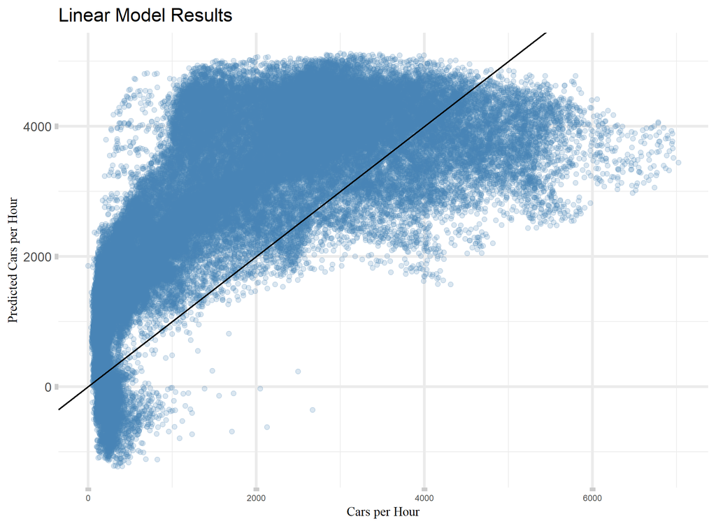

The results for the *linear model* should be a somewhat straight line, and not a manatee-like distribution (save the manatees). As predicted, the *linear model* did not perform well at predicting non-linear data.

### Random Forest

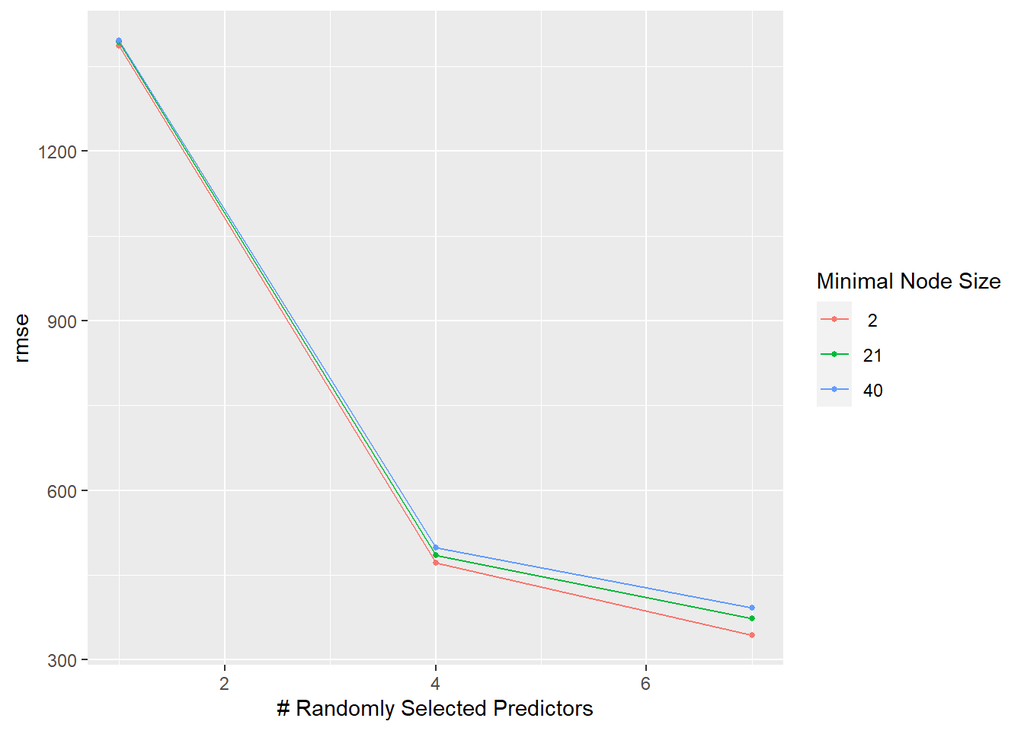

```r
# Random forest
rf_tuned <- read_rds("rf_results.rds")
autoplot(rf_tuned, metric = "rmse")
```

The node size does seem to help, but the maxiumum number of predictors (7) looks like it affects the accuracy the most.

### Boosted Tree

#### 1st Attempt

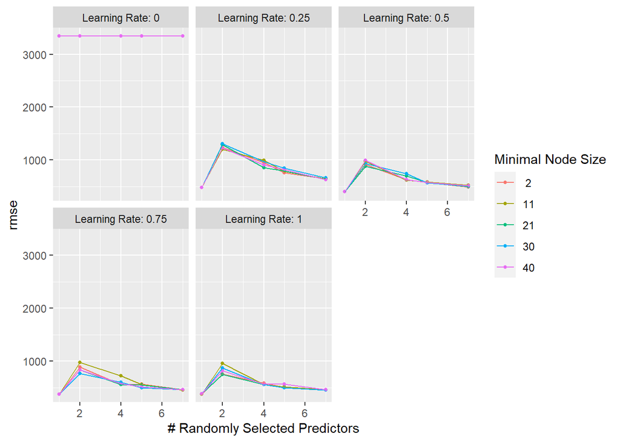

```r
bt_tuned <- read_rds("bt_results.rds")
autoplot(bt_tuned, metric = "rmse")
```

The minimal node size does not seem to be a major factor, but the learn rate is certainly an important consideration. Having a learn rate of 0 and 1 are basically throw-away values, so I limited the range of the learn rate in the second iteration to generate better results.

#### 2nd Attempt

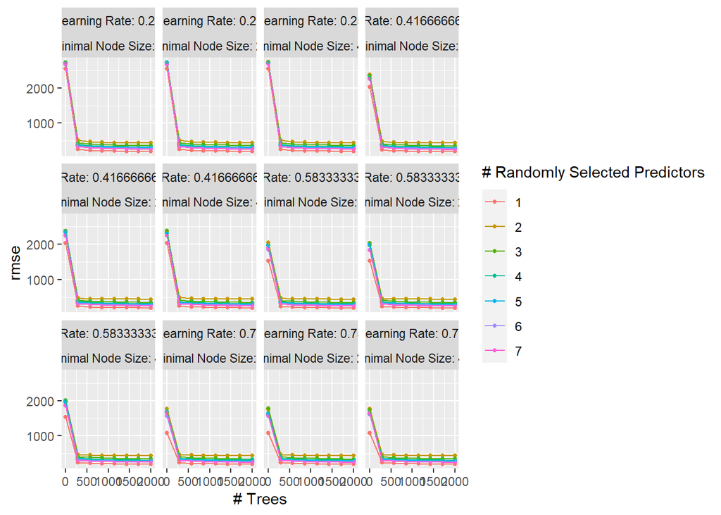

```r
bt_tuned_adj <- read_rds("bt_results_adjusted.rds")
autoplot(bt_tuned_adj, metric = "rmse")
```

### Nearest Neighbor

#### 1st Attempt

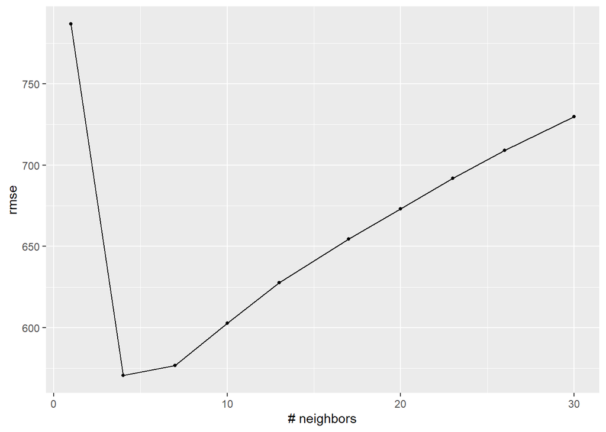

```r
nn_tuned <- read_rds("nn_results.rds")
autoplot(nn_tuned, metric = "rmse") +
  labs(x = "# neighbors")
```

This plot looks much different than what I was expecting. The error rate looks to rapidly increase with the more `neighbors` included. I decided to rerun this with much less total neighbors to see where the best really is.

#### 2nd Attempt

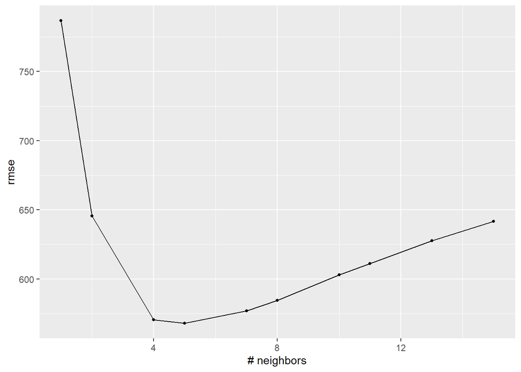

```r
nn_tuned_reduced <- read_rds("nn_results_reduced.rds")
autoplot(nn_tuned_reduced, metric = "rmse") +
  labs(x = "# neighbors")
```

Although this model is not the best, reducing the range for `neighbors` was certainly a worthwhile improvement to the first attempt.

## Comparing Model Results

```r
show_best(rf_tuned, metric = "rmse")
```

```
## # A tibble: 5 x 8
##    mtry min_n .metric .estimator  mean     n std_err .config
##   <int> <int> <chr>   <chr>      <dbl> <int>   <dbl> <chr>
## 1     7     2 rmse    standard    343.    10   0.912 Preprocessor1_Model3
## 2     7    21 rmse    standard    373.    10   1.01  Preprocessor1_Model6
## 3     7    40 rmse    standard    392.    10   1.12  Preprocessor1_Model9
## 4     4     2 rmse    standard    472.    10   1.27  Preprocessor1_Model2
## 5     4    21 rmse    standard    485.    10   1.06  Preprocessor1_Model5
```

```r
show_best(bt_tuned, metric = "rmse")
```

```
## # A tibble: 5 x 9
##    mtry min_n learn_rate .metric .estimator  mean     n std_err .config
##   <int> <int>      <dbl> <chr>   <chr>      <dbl> <int>   <dbl> <chr>
## 1     1     2       0.75 rmse    standard    374.    24    1.41 Preprocessor1_M~
## 2     1    11       0.75 rmse    standard    374.    24    1.36 Preprocessor1_M~
## 3     1    30       0.75 rmse    standard    374.    24    1.21 Preprocessor1_M~
## 4     1    21       0.75 rmse    standard    374.    24    1.51 Preprocessor1_M~
## 5     1    40       0.75 rmse    standard    375.    24    1.49 Preprocessor1_M~
```

```r
show_best(bt_tuned_adj, metric = "rmse")
```

```
## # A tibble: 5 x 10
##    mtry trees min_n learn_rate .metric .estimator  mean     n std_err .config
##   <int> <int> <int>      <dbl> <chr>   <chr>      <dbl> <int>   <dbl> <chr>
## 1     1  2000     2      0.583 rmse    standard    191.    40   0.347 Preproces~
## 2     1  2000    21      0.583 rmse    standard    192.    40   0.319 Preproces~
## 3     1  2000     2      0.75  rmse    standard    192.    40   0.344 Preproces~
## 4     1  2000    21      0.75  rmse    standard    192.    40   0.354 Preproces~
## 5     1  2000     2      0.417 rmse    standard    192.    40   0.325 Preproces~
```

```r
show_best(nn_tuned, metric = "rmse")
```

```
## # A tibble: 5 x 7
##   neighbors .metric .estimator  mean     n std_err .config
##       <int> <chr>   <chr>      <dbl> <int>   <dbl> <chr>
## 1         4 rmse    standard    571.    18    5.91 Preprocessor1_Model02
## 2         7 rmse    standard    577.    18    4.37 Preprocessor1_Model03
## 3        10 rmse    standard    603.    18    3.58 Preprocessor1_Model04
## 4        13 rmse    standard    628.    18    2.94 Preprocessor1_Model05
## 5        17 rmse    standard    654.    18    2.41 Preprocessor1_Model06
```

```r
show_best(nn_tuned_reduced, metric = "rmse")
```

```
## # A tibble: 5 x 7
##   neighbors .metric .estimator  mean     n std_err .config
##       <int> <chr>   <chr>      <dbl> <int>   <dbl> <chr>
## 1         5 rmse    standard    568.    18    5.36 Preprocessor1_Model04
## 2         4 rmse    standard    571.    18    5.91 Preprocessor1_Model03
## 3         7 rmse    standard    577.    18    4.37 Preprocessor1_Model05
## 4         8 rmse    standard    584.    18    4.13 Preprocessor1_Model06
## 5        10 rmse    standard    603.    18    3.58 Preprocessor1_Model07
```

The *Adjusted Boosted Trees model* performed much better than the first attempt at the *Boosted Trees model*, cutting the *rmse* practically in half. The *Adjusted Nearest Neighbor model* outperformed the *Nearest Neighbor model*, but only slightly. I tried to make an adjusted *Random Forest* model, but I ran into memory constraints with my data set being so large. Therefore, there was only one iteration of it (it interestingly outperformed my first attempt at the *Boosted Trees model*).

## Looking at Model Results for Class and Speed

I would have liked to have run more models, but with the impending doom of the quarter ending, I ran the best performing model for `Volume` (*Boosted Trees*) and ran it for `Class` and `Speed`. These are the results I obtained:

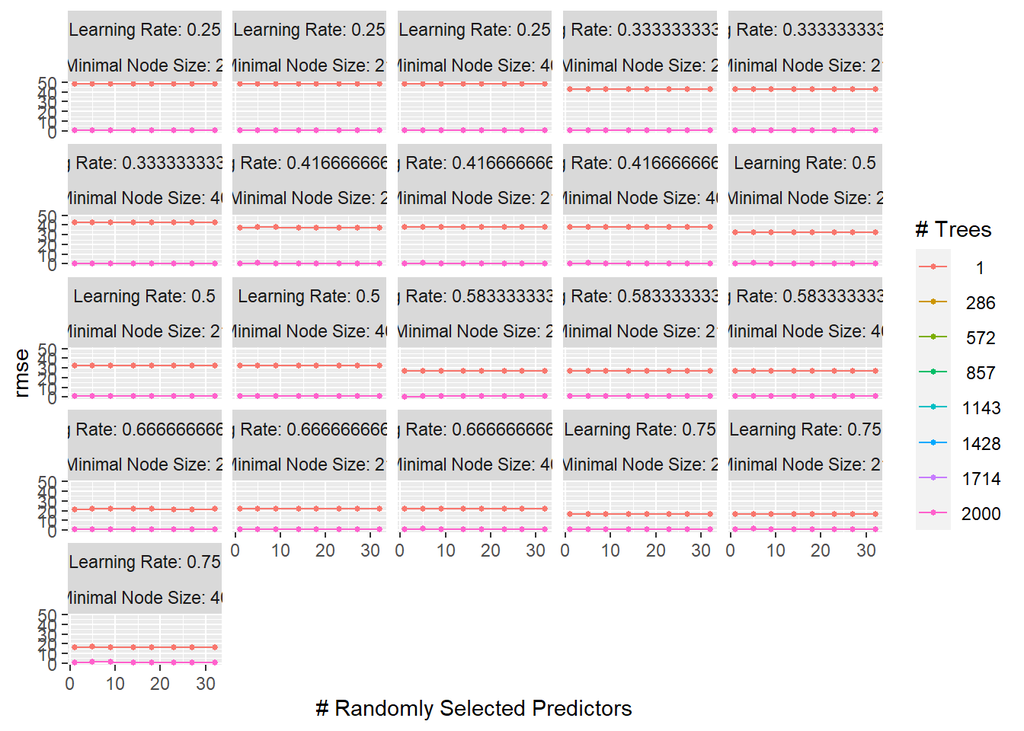

```r
# Plotting Fitted data
pike_class_speed_tuned <- read_rds("class_speed_work/bt_results_avg_speed.rds")
autoplot(pike_class_speed_tuned, metric = "rmse")
```

With many scenarios, it is a little tricky to see, but showing the best models shows that several of the scenarios have the same mean *RMSE* values.

```r
show_best(pike_class_speed_tuned, metric = "rmse")
```

```
## # A tibble: 5 x 10
##    mtry trees min_n learn_rate .metric .estimator  mean     n std_err .config
##   <int> <int> <int>      <dbl> <chr>   <chr>      <dbl> <int>   <dbl> <chr>
## 1     1  1143     2       0.25 rmse    standard   0.378    60 0.00721 Preproces~
## 2     1  1428     2       0.25 rmse    standard   0.378    60 0.00721 Preproces~
## 3     1  1714     2       0.25 rmse    standard   0.378    60 0.00721 Preproces~
## 4     1  2000     2       0.25 rmse    standard   0.378    60 0.00721 Preproces~
## 5     1   857     2       0.25 rmse    standard   0.378    60 0.00721 Preproces~
```

## Looking at Model Prediction Results

### Volume

```r
best_model <- read_rds("best_model_predictions.rds")
best_model
```

```
## # A tibble: 1 x 3
##   .metric .estimator .estimate
##   <chr>   <chr>          <dbl>
## 1 rmse    standard       1411.
```

### Class and Speed

```r
bt_class_speed_predictions <- read_rds("bt_model_predictions.rds")
bt_class_speed_predictions
```

```
## # A tibble: 1 x 3
##   .metric .estimator .estimate
##   <chr>   <chr>          <dbl>
## 1 rmse    standard        1.01
```

To quote my fellow Bostonians, the model used to predict the `cars_per_hour` did “wicked bad” while the model used to predict the `daily_sum` did “wicked good”. One possible difference could be that I removed `year` from the `cars_per_hour` because I wanted to cut back on the number of predictors. Perhaps if it could have accounted for the yearly increases, it would have performed better. However, the results are fairly clear that we were not just imagining it, but 2020 was truly an unprecedented year.

## Test Data Reveal

### Looking at Yearly Average Speeds in January & February versus April versus November

```r
# Examining Yearly Average Speeds in January and February
pike_class_speed_joined %>%
  filter(!is.na(daily_sum)) %>%
  filter(month == 1 | month == 2) %>%
  group_by(c(year)) %>%
  summarize(
    mean_daily_sum = mean(daily_sum),
    median_daily_sum = median(daily_sum)
  )
```

```
## # A tibble: 4 x 3
##   `c(year)` mean_daily_sum median_daily_sum
##       <dbl>          <dbl>            <dbl>
## 1      2017           65.0             65.4
## 2      2018           65.4             66.1
## 3      2019           65.2             65.8
## 4      2020           66.0             66.5
```

```r
# Examining Yearly Average Speeds in April
pike_class_speed_joined %>%
  filter(!is.na(daily_sum)) %>%
  filter(month == 4) %>%
  group_by(c(year)) %>%
  summarize(
    mean_daily_sum = mean(daily_sum),
    median_daily_sum = median(daily_sum)
  )
```

```
## # A tibble: 4 x 3
##   `c(year)` mean_daily_sum median_daily_sum
##       <dbl>          <dbl>            <dbl>
## 1      2017           64.2             64.7
## 2      2018           64.2             65.0
## 3      2019           64.2             64.7
## 4      2020           72.0             73.1
```

```r
# Examining Yearly Average Speeds in November
pike_class_speed_joined %>%
  filter(!is.na(daily_sum)) %>%
  filter(month == 11) %>%
  group_by(c(year)) %>%
  summarize(
    mean_daily_sum = mean(daily_sum),
    median_daily_sum = median(daily_sum)
  )
```

```
## # A tibble: 5 x 3
##   `c(year)` mean_daily_sum median_daily_sum
##       <dbl>          <dbl>            <dbl>
## 1      2016           64.4             64.9
## 2      2017           64.5             64.4
## 3      2018           63.5             64.2
## 4      2019           64.0             64.5
## 5      2020           70.6             72.1
```

### Looking at Total Number of Vehicles in April and November in 2017 and 2020

```r
# Examining Total Number of Cars in April
pike_class_speed_joined %>%
  filter(month == 4 & year == 2017) %>%
  select(total)
```

```
## # A tibble: 200 x 6
## # Groups:   total, direction, location, year, month, day [200]
##    direction location  year month   day total
##    <chr>     <chr>    <dbl> <dbl> <dbl> <dbl>
##  1 EB        AET09     2017     4     3 55419
##  2 EB        AET09     2017     4     4 53169
##  3 EB        AET09     2017     4     5 59360
##  4 EB        AET09     2017     4     6 58283
##  5 EB        AET09     2017     4     7 65447
##  6 EB        AET09     2017     4    10 57449
##  7 EB        AET09     2017     4    11 59673
##  8 EB        AET09     2017     4    12 61067
##  9 EB        AET09     2017     4    13 63771
## 10 EB        AET09     2017     4    14 67158
## # ... with 190 more rows
```

```r
pike_class_speed_joined %>%
  filter(month == 4 & year == 2020) %>%
  select(total)
```

```
## # A tibble: 220 x 6
## # Groups:   total, direction, location, year, month, day [220]
##    direction location  year month   day total
##    <chr>     <chr>    <dbl> <dbl> <dbl> <dbl>
##  1 EB        AET09     2020     4     1 20246
##  2 EB        AET09     2020     4     2 18772
##  3 EB        AET09     2020     4     3 18702
##  4 EB        AET09     2020     4     6 18921
##  5 EB        AET09     2020     4     7 19216
##  6 EB        AET09     2020     4     8 18476
##  7 EB        AET09     2020     4     9 18069
##  8 EB        AET09     2020     4    10 19076
##  9 EB        AET09     2020     4    13 16218
## 10 EB        AET09     2020     4    14 20299
## # ... with 210 more rows
```

```r
# Examining Yearly Average Speeds in November
pike_class_speed_joined %>%
  filter(month == 11 & year == 2017) %>%
  select(total)
```

```
## # A tibble: 220 x 6
## # Groups:   total, direction, location, year, month, day [220]
##    direction location  year month   day total
##    <chr>     <chr>    <dbl> <dbl> <dbl> <dbl>
##  1 EB        AET09     2017    11     1 57569
##  2 EB        AET09     2017    11     2 58551
##  3 EB        AET09     2017    11     3 62793
##  4 EB        AET09     2017    11     6 53960
##  5 EB        AET09     2017    11     7 54714
##  6 EB        AET09     2017    11     8 55294
##  7 EB        AET09     2017    11     9 60835
##  8 EB        AET09     2017    11    10 64995
##  9 EB        AET09     2017    11    13 53356
## 10 EB        AET09     2017    11    14 54480
## # ... with 210 more rows
```

```r
pike_class_speed_joined %>%
  filter(month == 11 & year == 2020) %>%
  select(total)
```

```
## # A tibble: 210 x 6
## # Groups:   total, direction, location, year, month, day [210]
##    direction location  year month   day total
##    <chr>     <chr>    <dbl> <dbl> <dbl> <dbl>
##  1 EB        AET09     2020    11     2 40894
##  2 EB        AET09     2020    11     3 40857
##  3 EB        AET09     2020    11     4 43164
##  4 EB        AET09     2020    11     5 43600
##  5 EB        AET09     2020    11     6 45736
##  6 EB        AET09     2020    11     9 40836
##  7 EB        AET09     2020    11    10 41502
##  8 EB        AET09     2020    11    11 38608
##  9 EB        AET09     2020    11    12 41837
## 10 EB        AET09     2020    11    13 43155
## # ... with 200 more rows
```